# Data Science Capstone Project

Week 2 - Exploratory Analysis & Initial N-Gram Model

Paul Ringsted

2nd March 2019

# 1 Synopsis

The goal of this project is to create a text prediction model/algorithm and shiny app demonstrator to perform text prediction, using a “corpus” of 3 documents as a source for training data - extracts from blogs, news and twitter.

This prediction model will likely utilize a pre-processed distribution of N-grams (sequence of N words) to perform a lookup based on text entered so far; the last N-1 words typed by the user would be used to lookup the most frequent (hence, most likely) N-gram to predict the Nth word that comes next. If no match can be found, the process is repeated with the next shortest N-gram and so forth.

In this report we present:

1. Analysis of line/word counts of the entire corpus (using a Document Feature Matrix) and examination of prevalence of stopwords (the, and etc).
2. Analysis of the distribution of N-grams up to N=5 for a random 10% sample of the Corpus.
3. A basic model for ranking and predicting N-grams, along with examples.

The main technical challenge of this project is the volume of data provided in the corpus which will generate a large number of N-grams and will be difficult to fully process on non-enterprise hardware. This analysis used the quanteda package, which provides fast multi-threaded tokenization of the corpus, and the data.table package to efficiently process the N-gram output from quanteda.

Determining the optimal value of ‘N’, and the most efficient data structures and algorithm, will follow in next stages of the project. However this initial analysis yielded some ideas to improve performance, for further exploration:

- Reduce the population of N-gram predictions to just cover the small population (<1%) of words which account for 90% of the words in the corpus.
- Reduce the population of N-gram predictions by either reducing N, or discarding the population of low frequency (less likely) N-grams which grows significantly larger as N increases.
- Representation of N-grams as lookup/hash tables to reduce redundancy in the data tables and improve performance, both during pre-processing and application runtime.

## 1.1 References

Note: Code executed in this report is not shown, but is available at https://github.com/ringspagit/DS10_Capstone_NLP

The following papers were key references for guidance on how to approach this project:

*Explanation of N-Grams and Natural Language Processing:*

https://lagunita.stanford.edu/c4x/Engineering/CS-224N/asset/slp4.pdf

*Notes from Len Greski, on best tools to tackle this project:*

https://github.com/lgreski/datasciencectacontent/blob/master/markdown/capstone-simplifiedApproach.md

*Quanteda Cheat Sheet:*

https://github.com/rstudio/cheatsheets/raw/master/quanteda.pdf

# 2 Initial Corpus Analysis

Using basic ‘wc’ command gives initial view of the raw data files as follows, without any cleaning. Each file contains >30million words (spread over twice the number of lines in the twitter data).

Line/Word/Byte Counts of Corpus Files

| File | Lines | Words | Bytes |
| --- | --- | --- | --- |
| en_US.blogs.txt | 899,288 | 37,334,690 | 210,160,014 |
| en_US.news.txt | 1,010,242 | 34,372,720 | 205,811,889 |
| en_US.twitter.txt | 2,360,148 | 30,374,206 | 167,105,338 |
| total | 4,269,678 | 102,081,616 | 583,077,241 |

We will consider all 3 files as part of a single population, using quanteda options to reduce to lower case, remove symbols and punctuation (which preserves apostrophes and hyphenation), and generate the token list. To help with basic analysis we construct a basic document feature matrix (DFM), though the eventual application will use N-gram lists not the DFM.

At this stage, we are **not removing profanities** in order to not create invalid N-gram relationships due to missing words, and to focus on more important aspects of model construction.

For the purposes of analysis, DFMs both including and excluding stopwords were created in order to better understand the word distribution.

Word Count of Corpus

| Total words (orig) | Scope | Total words (cleaned) | Unique Words | Unique % of Total |
| --- | --- | --- | --- | --- |
| 102,081,616 | With Stopwords | 101,514,530 | 924,980 | 0.9 |
|  | Without Stopwords | 56,534,377 | 924,805 | 1.6 |
|  | Difference | 44,980,153 | 175 |  |

## 2.1 Observations on the Corpus

See Appendix for wordclouds, and histograms of top features and N-grams. Following is a plot of the CDF showing how many unique words are required to cover the corpus, reflecting the 50% and 90% quantiles for the case including stopwords:

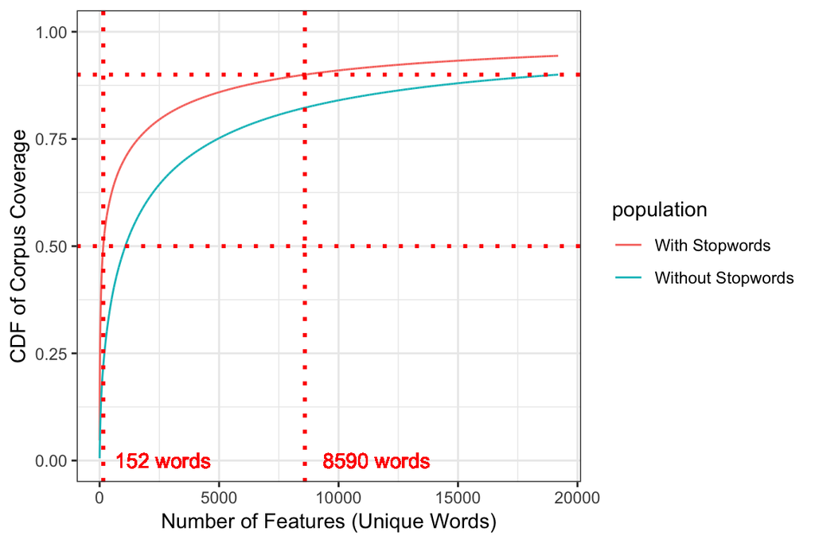

CDF of Corpus Coverage by Features (Unique Words)

Note:

- 175 of the words are stopwords. These account for 44% of the words in the Corpus
- Including stopwords:
  - 50% of the word coverage comes from the top 152 words (0.02% of the population)
  - **90% of the word coverage comes from the top 8590 words (0.93% of the population)**
- Excluding stopwords:
  - 50% of the word coverage comes from the top 1076 words (0.12% of the population)
  - 90% of the word coverage comes from the top 19190 words (2.08% of the population)
- For purpose of contextual analysis it would seem removal of stopwords makes sense, however the focus of this project is on text prediction so stopwords likely need to remain in the N-gram relationships.
- **Based on this information, one avenue to explore in optimization of the prediction model is to reduce the N-gram model by just focusing on the smaller subset of word predictions which cover a large proportion of the observed language.**

# 3 Initial N-Gram Analysis

Generating N-grams for the entire corpus is extremely resource intensive and time-consuming. A procedure was written to process all 3 corpus files of ~4million lines combined, and randomly assign them to 10 files, which can then be used for (a) analysis of partial population; (b) chunked up processing of N-grams for majority or total population; (c) splitting the population into training and test datasets. For an understanding of the N-gram distribution and to build basic initial model for prediction, we loaded and analyzed one of these files (i.e. random 10% of the corpus).

For the initial prediction model we will calculate probability P() using relative frequency i.e. the observed frequency C() of the N-gram divided by the observed frequency of the prefix n-1 words (“base”). Using the notation of $w_1...w_n$ to mean a sequence of n words $w_i$:

$P(w_1...w_n) = \frac{C(w_1...w_n)}{C(w_1...w_{n-1})}$

Processing steps used are:

1. Generate all N-grams with N=1:5 (N=1 (unigrams) are needed in the dataset to provide the ‘base’ for bigrams)
2. Summarize to unique N-grams with frequency count ($ngram\_freq$)
3. Split the N-gram into it’s constituent ‘base’ (i.e. $w_1...w_{n-1}$) and ‘next word’ ($w_n$)
4. Calculate the frequency count of the ‘base’ as an N-gram in the dataset ($base\_freq$)
5. Calculate the probability of the N-gram as its frequency divided by the frequency of the ‘base’ ($\frac{ngram\_freq}{base\_freq}$)
6. For each ‘base’, rank its possible N-gram outcomes by probability from highest to lowest ($ngram\_prob\_rank$)

From this data we can then focus on the smaller subset of ‘top ranked’ N-grams ($ngram\_prob\_rank = 1$).

Note that the number of top ranked N-grams for N=n will (in theory) be the number of unique N-grams for N=(n-1), and for N=1 there is only 1 top-ranked N-gram, which is by definition the most frequent feature in the corpus (“the”). In practice there is a difference of 1 for top-ranked trigrams vs. bigrams and so on. This analysis ignores beginning and start of lines, so the N-gram sequence generated by quanteda is just a continuous string of the corpus provided. However on the last line of corpus, if the final bigram is a singular example in the corpus, it will not appear as a ‘base’ prefix in a corresponding trigram, and so forth with larger terminal N-grams. It just so happened in this random sample that the final line was “Seriously, who <profanity>”, a unique phrase, which accounts for the difference of 1 in the counts. We will ignore this edge condition for now.

This now gives us a basic framework to determine, given an input of $(w_1...w_{n-1})$ words, what is the most likely N-gram which extends the sentence to ${w_n}$, for $n\leq5$.

Results of this processing for the 10% sample corpus are shown below. Note the significant increase in unique and top-ranked N-grams, as N increases.

N-gram Distribution in Random 10% Corpus Sample

| N-gram | Total N-grams | Unique N-grams | Unique % Of Total | Top Ranked N-grams | Unique N-grams Population Coverage 50%-ile | Unique N-grams Population Coverage 50%-ile % of Unique | Unique N-grams Population Coverage 90%-ile | Unique N-grams Population Coverage 90%-ile % of Unique |
| --- | --- | --- | --- | --- | --- | --- | --- | --- |
| 1 | 10,135,628 | 229,705 | 2.3 | 1 | 152 | 0.1 | 8,531 | 3.7 |
| 2 | 10,135,627 | 2,987,219 | 29.5 | 229,705 | 49,377 | 1.7 | 1,973,657 | 66.1 |
| 3 | 10,135,626 | 7,114,408 | 70.2 | 2,987,218 | 2,046,596 | 28.8 | 6,100,846 | 85.8 |
| 4 | 10,135,625 | 9,302,692 | 91.8 | 7,114,407 | 4,234,880 | 45.5 | 8,289,130 | 89.1 |
| 5 | 10,135,624 | 9,936,517 | 98.0 | 9,302,691 | 4,868,706 | 49.0 | 8,922,955 | 89.8 |
| Total | 50,678,130 | 29,570,541 | 58.3 | 19,634,022 |  |  |  |  |

## 3.1 N-Gram Examples

The following are some illustrative examples of N-gram patterns generated using this method from this sample corpus:

N-Gram Example #1 (at the bottom of…)

| ngram | ngram_len | freq | base_word | next_word | base_freq | ngram_prob | ngram_prob_rank |
| --- | --- | --- | --- | --- | --- | --- | --- |
| at the bottom of the | 5 | 54 | at the bottom of | the | 96 | 0.5625000 | 1 |
| at the bottom of this | 5 | 12 | at the bottom of | this | 96 | 0.1250000 | 2 |
| at the bottom of my | 5 | 6 | at the bottom of | my | 96 | 0.0625000 | 3 |
| at the bottom of a | 5 | 6 | at the bottom of | a | 96 | 0.0625000 | 4 |
| at the bottom of your | 5 | 4 | at the bottom of | your | 96 | 0.0416667 | 5 |
| at the bottom of it | 5 | 3 | at the bottom of | it | 96 | 0.0312500 | 6 |
| at the bottom of their | 5 | 2 | at the bottom of | their | 96 | 0.0208333 | 7 |
| at the bottom of her | 5 | 2 | at the bottom of | her | 96 | 0.0208333 | 8 |
| at the bottom of our | 5 | 1 | at the bottom of | our | 96 | 0.0104167 | 9 |
| at the bottom of decker | 5 | 1 | at the bottom of | decker | 96 | 0.0104167 | 10 |
| at the bottom of each | 5 | 1 | at the bottom of | each | 96 | 0.0104167 | 11 |
| at the bottom of his | 5 | 1 | at the bottom of | his | 96 | 0.0104167 | 12 |
| at the bottom of an | 5 | 1 | at the bottom of | an | 96 | 0.0104167 | 13 |
| at the bottom of east | 5 | 1 | at the bottom of | east | 96 | 0.0104167 | 14 |
| at the bottom of everything | 5 | 1 | at the bottom of | everything | 96 | 0.0104167 | 15 |

N-Gram Example #2 (and a case of…)

| ngram | ngram_len | freq | base_word | next_word | base_freq | ngram_prob | ngram_prob_rank |
| --- | --- | --- | --- | --- | --- | --- | --- |
| and a case of beer | 5 | 2 | and a case of | beer | 2 | 1 | 1 |

| ngram | ngram_len | freq | base_word | next_word | base_freq | ngram_prob | ngram_prob_rank |
| --- | --- | --- | --- | --- | --- | --- | --- |
| speedskating | 1 | 2 |  | speedskating | 10,135,628 | 0.0000002 | 70,408 |
| of speedskating | 2 | 2 | of | speedskating | 200,404 | 0.0000100 | 6,726 |
| heart of speedskating | 3 | 2 | heart of | speedskating | 232 | 0.0086207 | 14 |
| the heart of speedskating | 4 | 2 | the heart of | speedskating | 183 | 0.0109290 | 10 |
| is the heart of speedskating | 5 | 1 | is the heart of | speedskating | 7 | 0.1428571 | 2 |
| it’s the heart of speedskating | 5 | 1 | it’s the heart of | speedskating | 2 | 0.5000000 | 1 |
| it’s the heart of the | 5 | 1 | it’s the heart of | the | 2 | 0.5000000 | 2 |

In Example #1 (all 5-grams starting with “at the bottom of”)

- There are 96 instances of the 4-gram, with 15 endings
- Most frequently, 54 of these cases end with “the”

In Example #2 (all 5-grams starting with “and a case of”)

- There are 2 instances of the 4-gram, with 1 ending, “beer”

In Example #3 (all N-grams ending with “speedskating” or starting with “it’s the heart of”)

- There is only 1 case which has an N-gram rank of 1, “it’s the heart of speedskating”, so only the phrase “it’s the heart of” will lead to a prediction of “speedskating”.
- Based on this data there were two possible predictions given this base word, both with equal frequencies, but the ranking pre-selected “speedskating” based on alphabetical order of ‘next_word’.
- One possible improvement to consider is to break ties using the frequency of ‘next_word’ in the corpus, which would make “the”, a more likely outcome here than “speedskating”.

## 3.2 Observations on N-Grams

# 4 Appendix - Figures

1. Word Cloud (Top 500), with Stopwords
2. Word Cloud (Top 500), without Stopwords
3. Top Features (Unigrams), with Stopwords
4. Top Features (Unigrams), without Stopwords
5. Top N-Grams (N=2,3,4,5) - note reduction in frequency scale for higher N

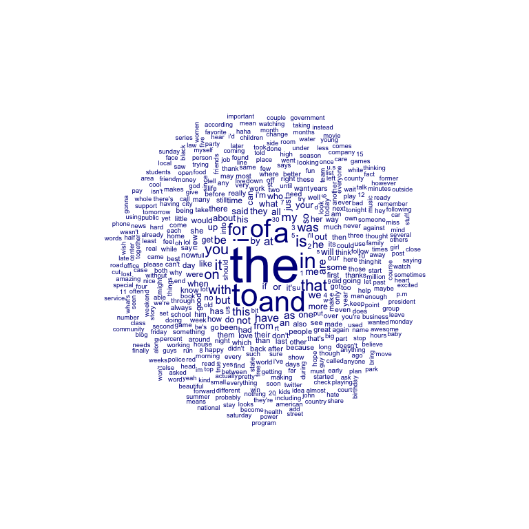

Word Cloud (Top 500), with Stopwords

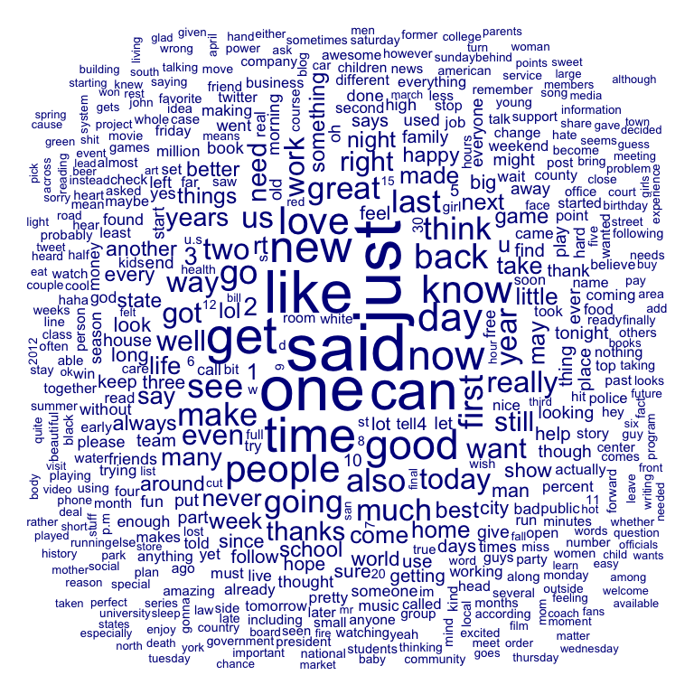

Word Cloud (Top 500), without Stopwords

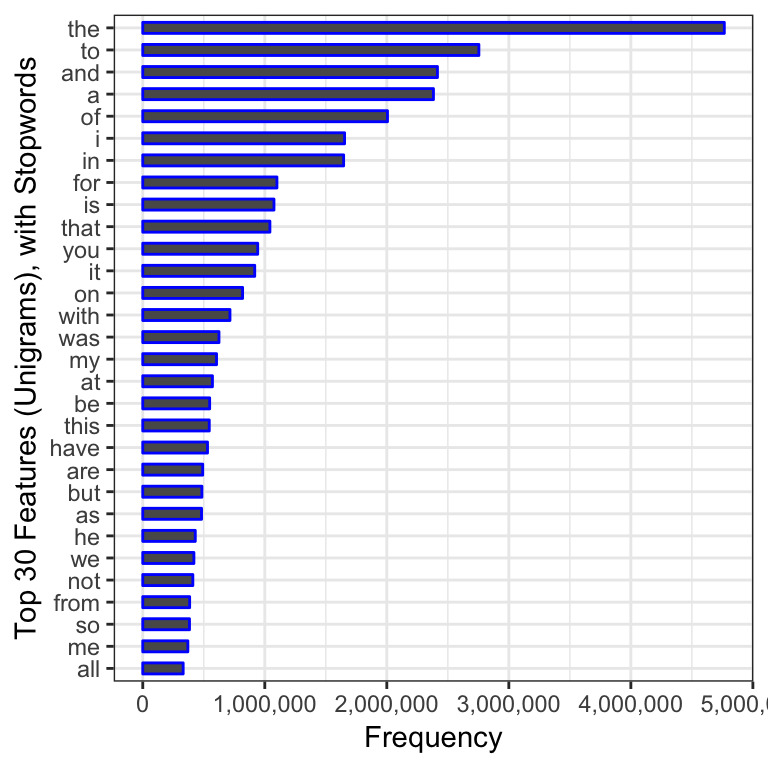

Top Features (Unigrams), with Stopwords

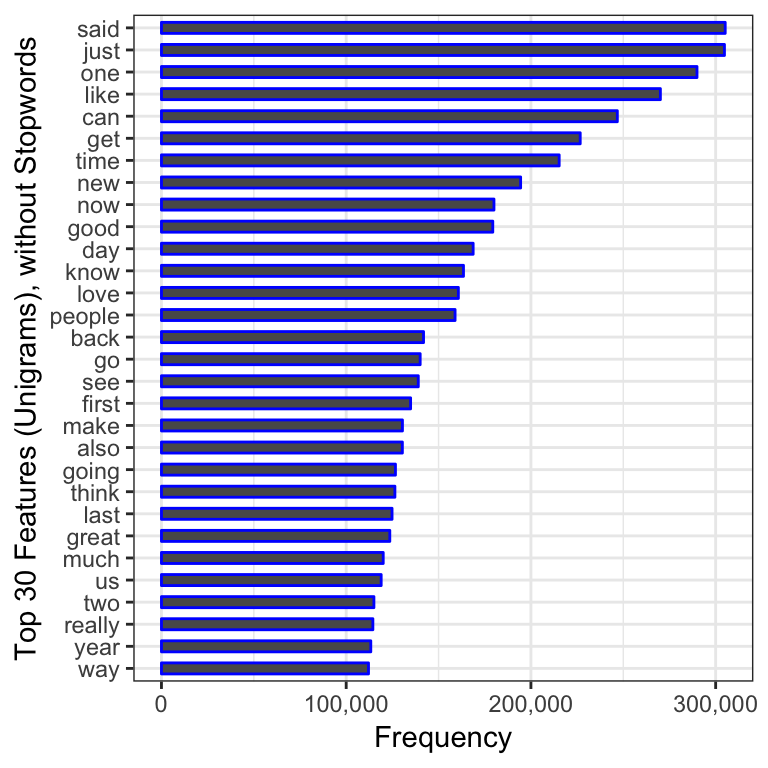

Top Features (Unigrams), without Stopwords

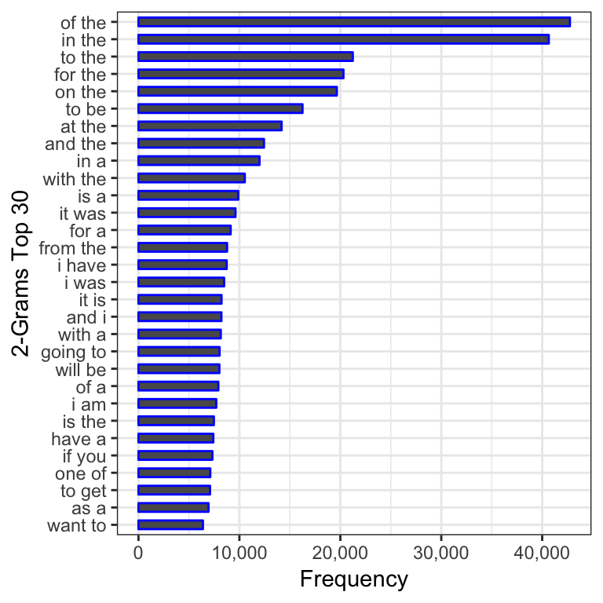

Top N-Grams

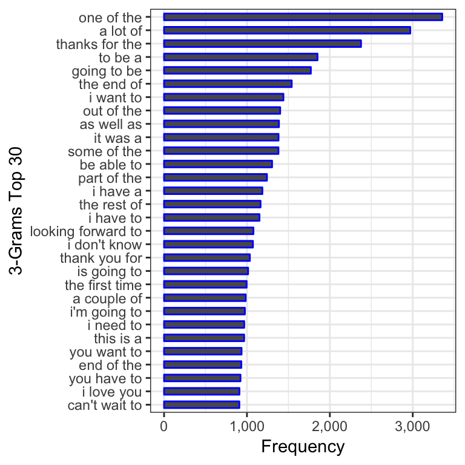

Top N-Grams

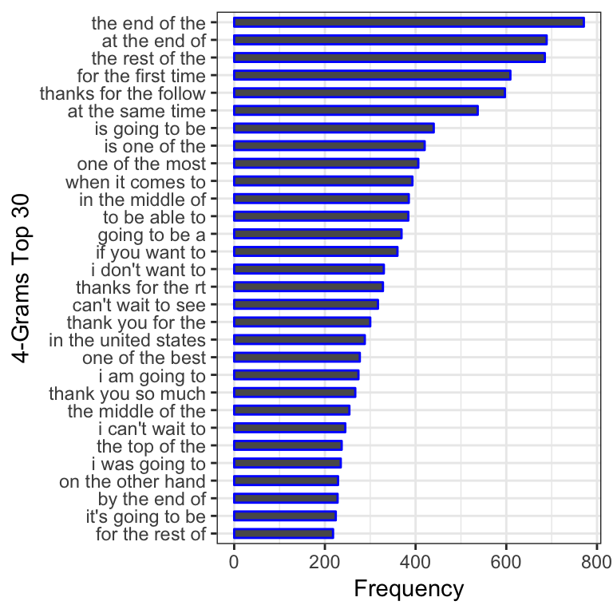

Top N-Grams

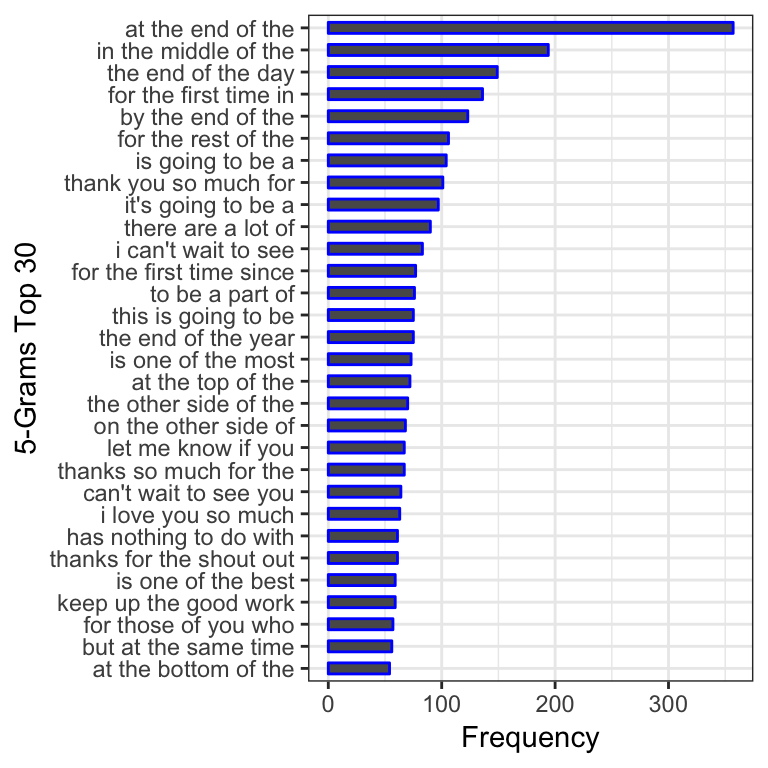

Top N-Grams